# Calls for Service During 2021 Compared to Pre-Pandemic Forecast - Incident Type

Matt Ashby, Nadia Kennar, Reka Solymosi

23/04/2021

## Abondended Phone Call

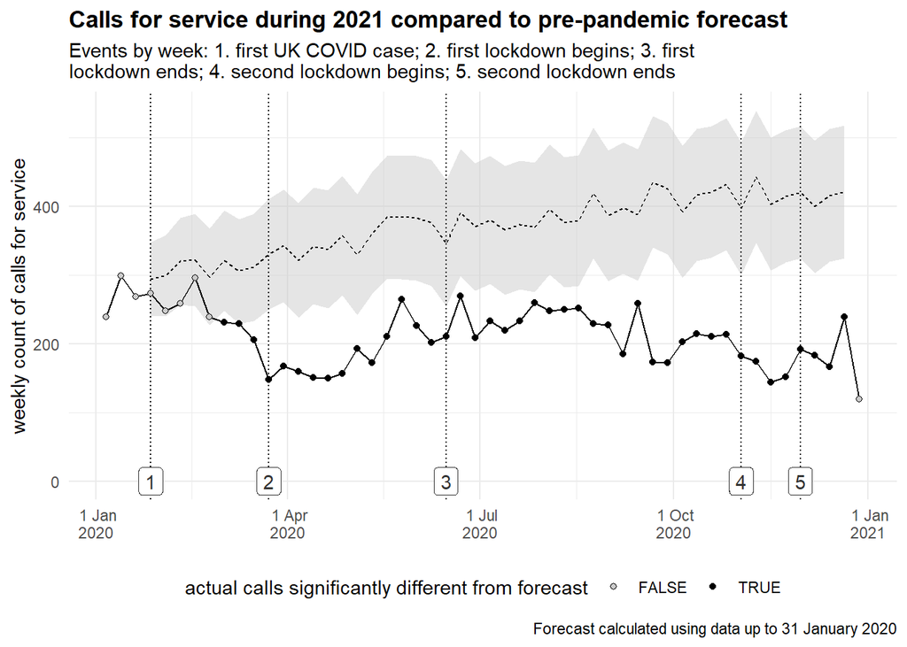

Majority of calls are significantly different from the forecast data. Less weekly calls received with a decreasing trend

## Admin

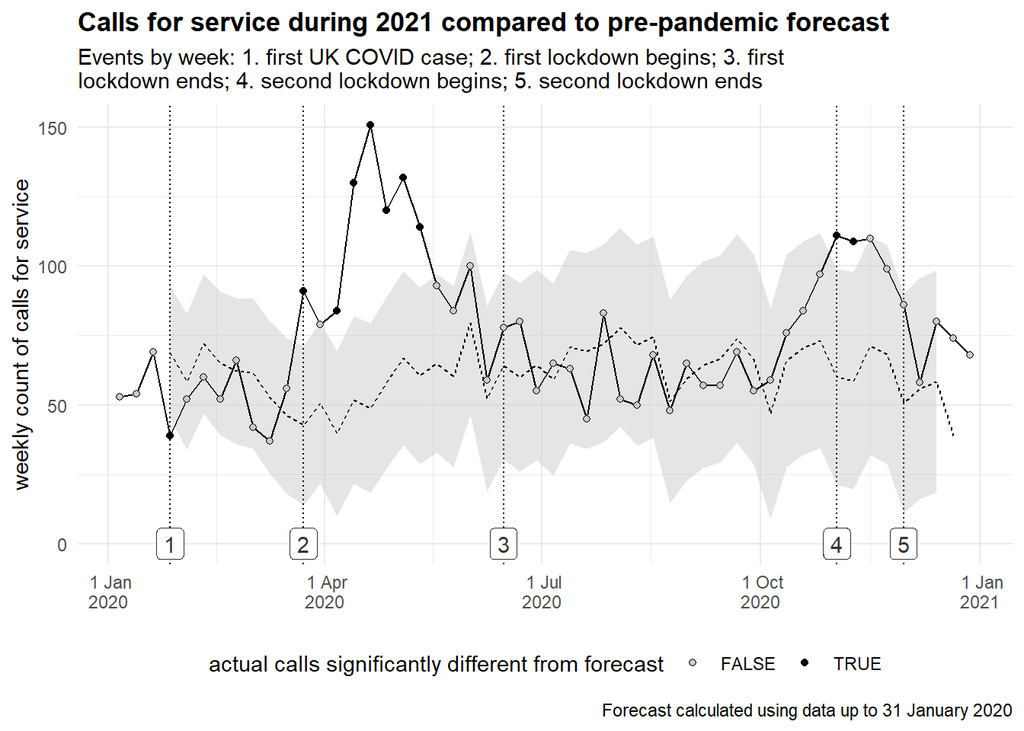

No significant differences in the weekly call counts from Admin. Nine time periods fall above of the conifdence intervals, mainly following the first UK lockdown

## Alarms

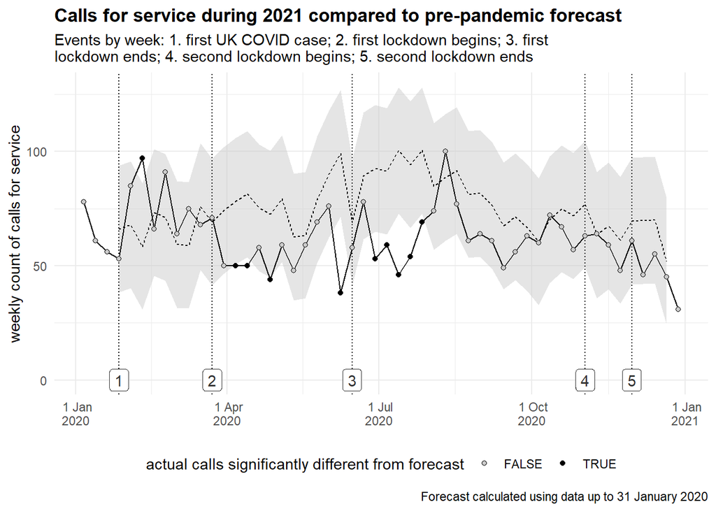

## Widlife Concern

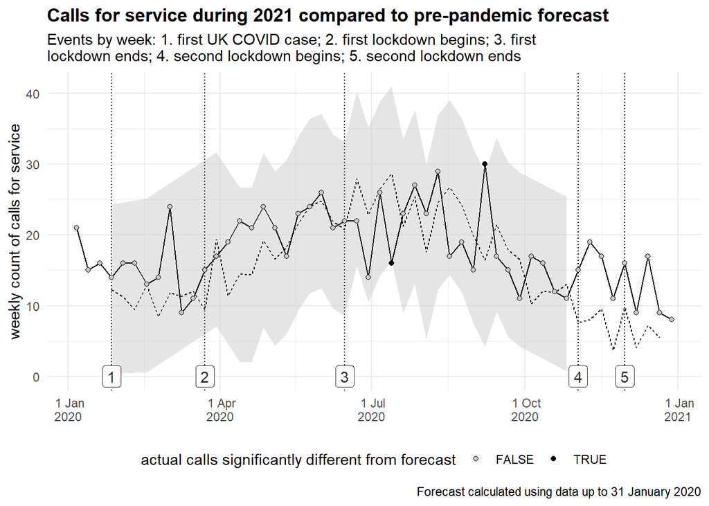

No significant differences between actual calls and forecast data

## ASB

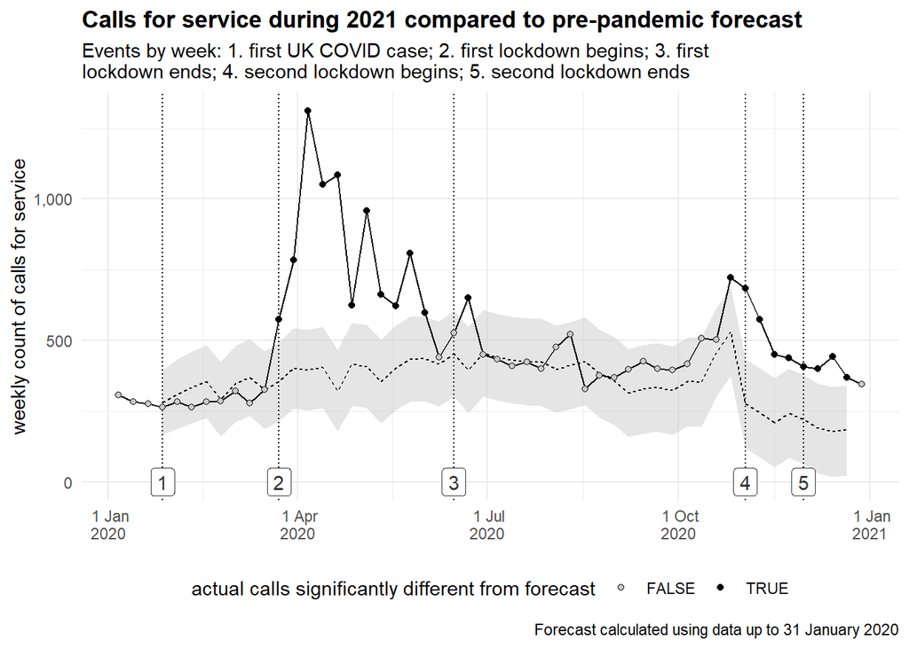

Over 20 point are considered significantly different form the forecast data as expected, mainly following the first lockdown and second lockdown. Supports literature with increase in ASB due to breaking restriction rules. Interesting to note the reduction of points outside the confidence intervals from the first lockdown to the second lockdown.

## Burglary - Commercial

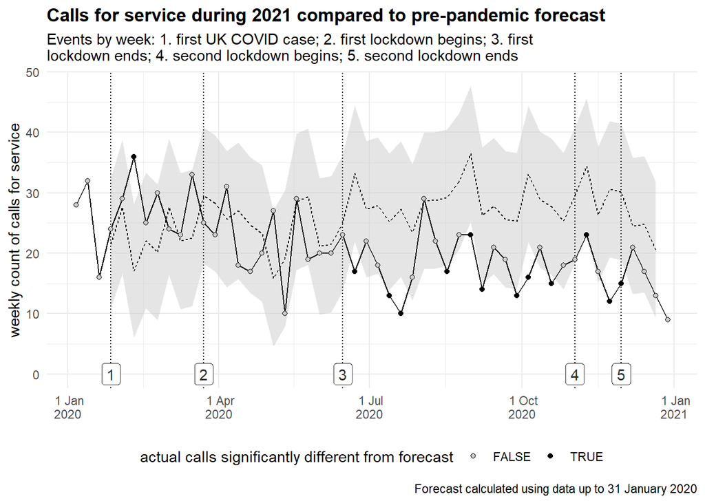

## Burglary - Residential

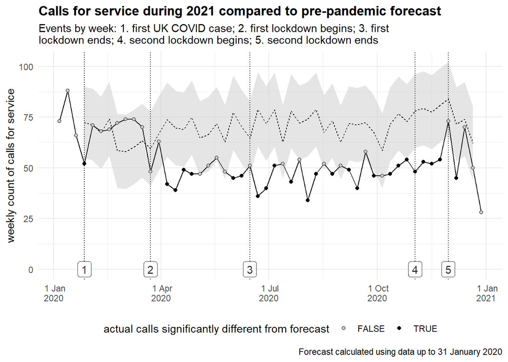

Majority of the calls are significantly different form the forecast, with a sharper reduction at the end of the second lockdown period. However, to say there is a clear difference in the trend is questionable

## Civil Disputes

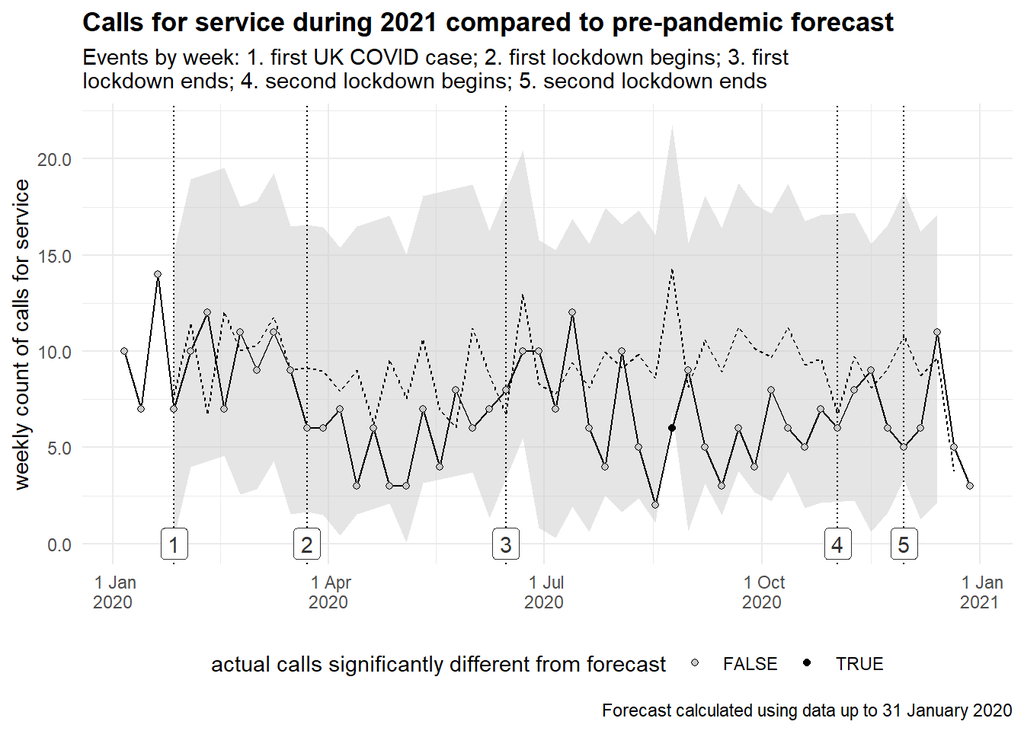

Actual calls are general lower than the forecast data but nothing too noticeable as only one point is significantly different from the forecast

## Police Safety

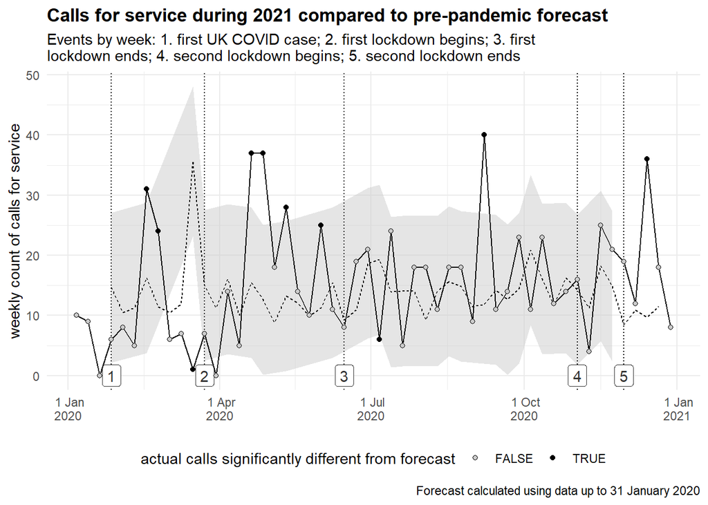

No significant differences in the trend between actual calls and foretasted data. A few points do sit above and below but this is expected with calls to service

## Minor Injuries

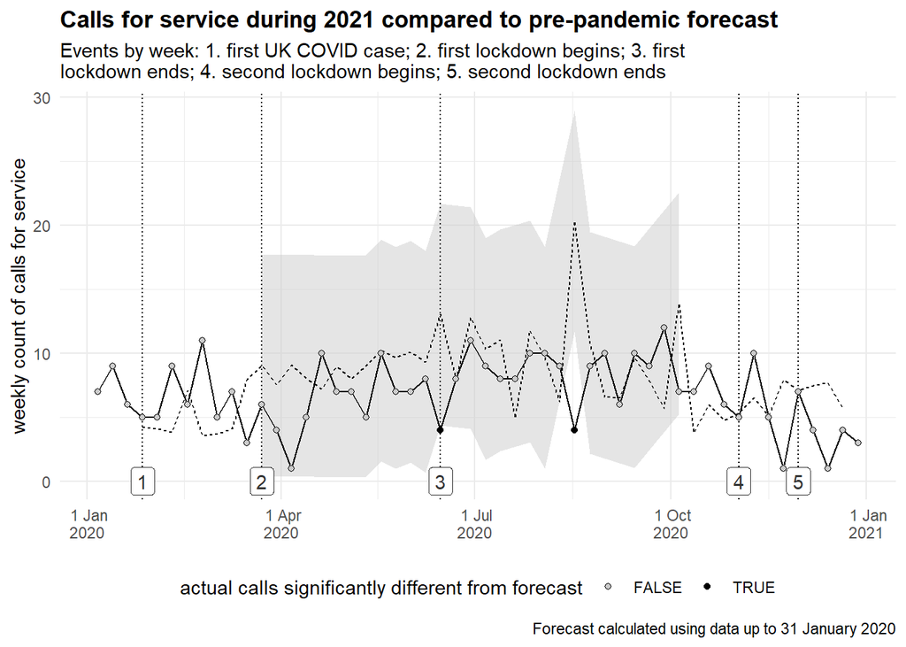

Foretasted trend seems to follow actual trend, nothing too different to note

## Complaints Against Police

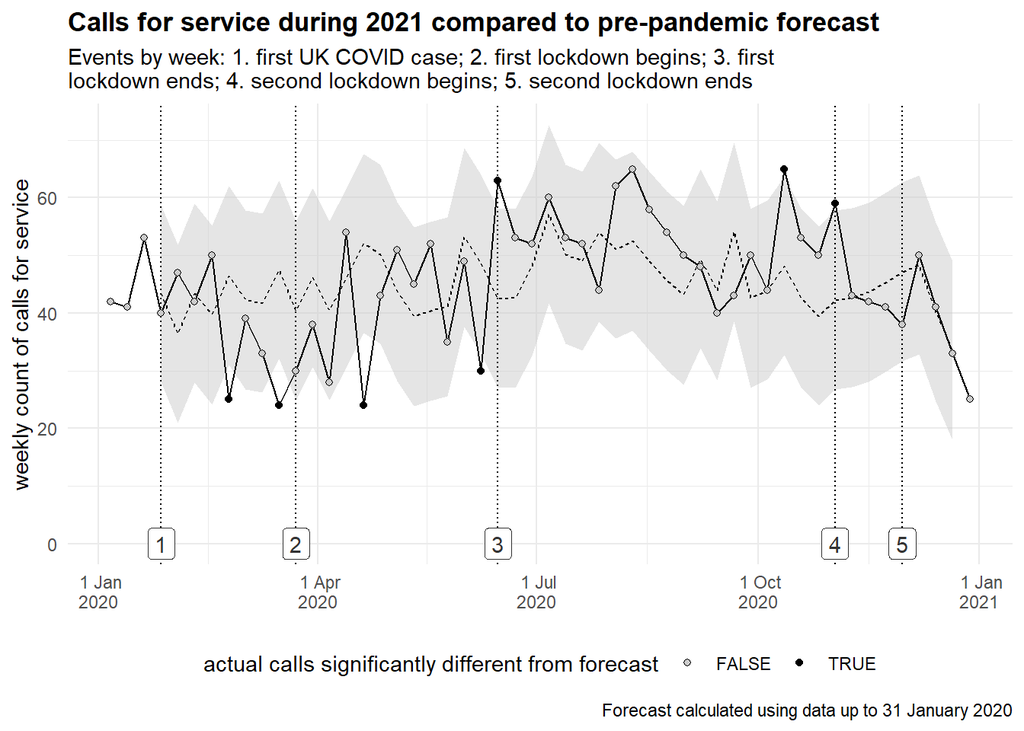

## Concern for Safety

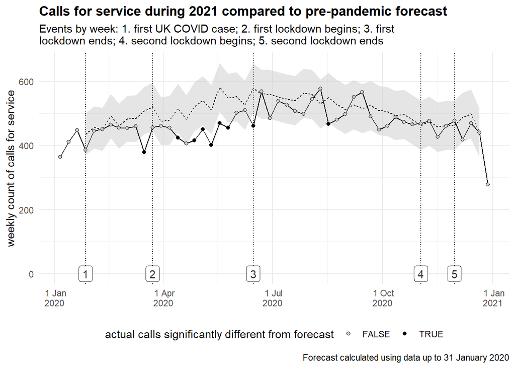

## Criminal Damage

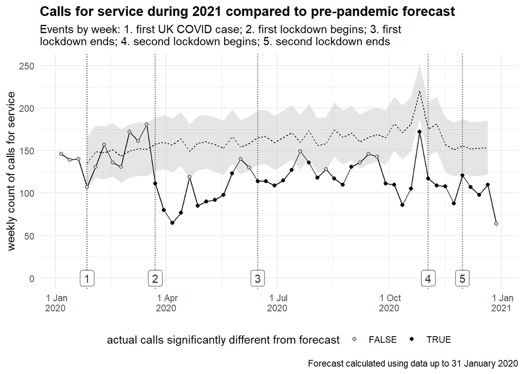

Following the first lockdown, actual calls of criminal damage are significantly different from the forecast falling below the lower 95% CIs.

## Domestic Incident

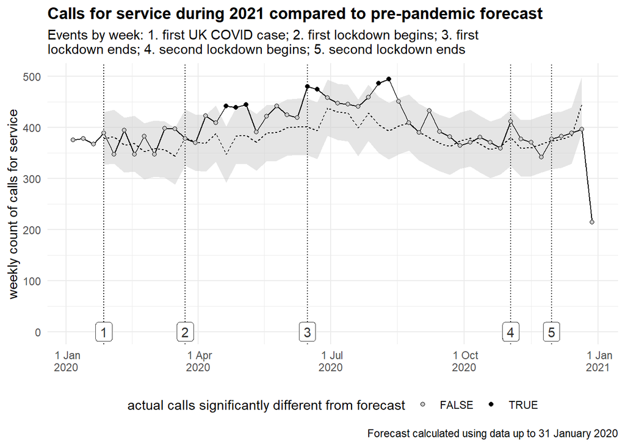

Only a few of the actual calls recorded for domestic incident fall above the upper bound of the 95% CI, mainly following the start of the first lockdown. Might have expected to see more calls falling outside the predicted data with literature stating that more people remain home?

## Drug Related Offences

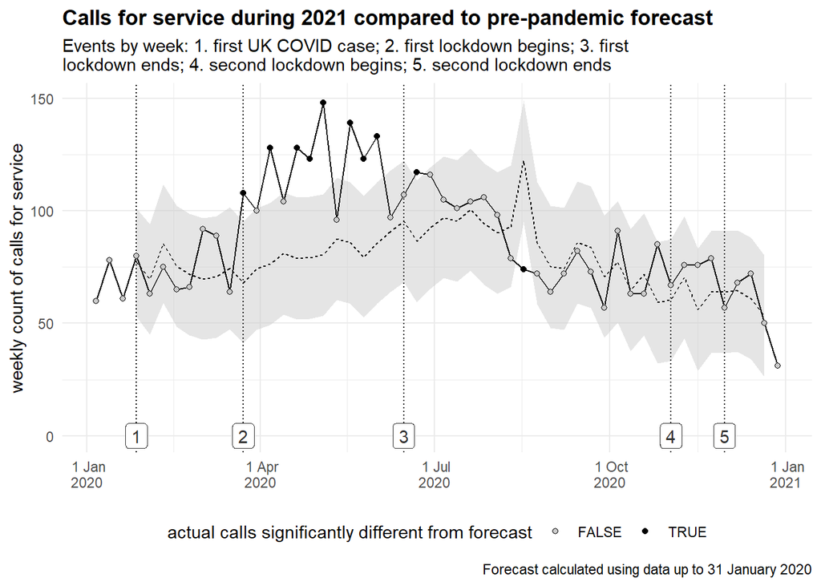

## Firearms

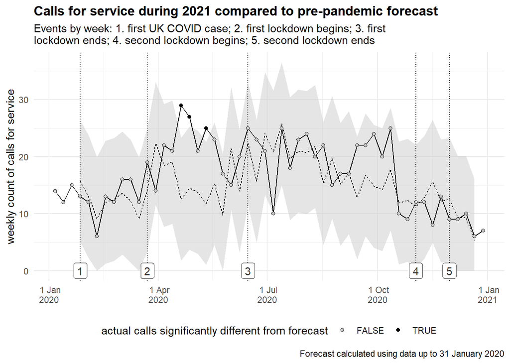

The overall patterns of actual crimes do not differ that significantly from the forecast results with the majority of points remaining within the upper and lower bounds of the confidence intervals.

## Fraud

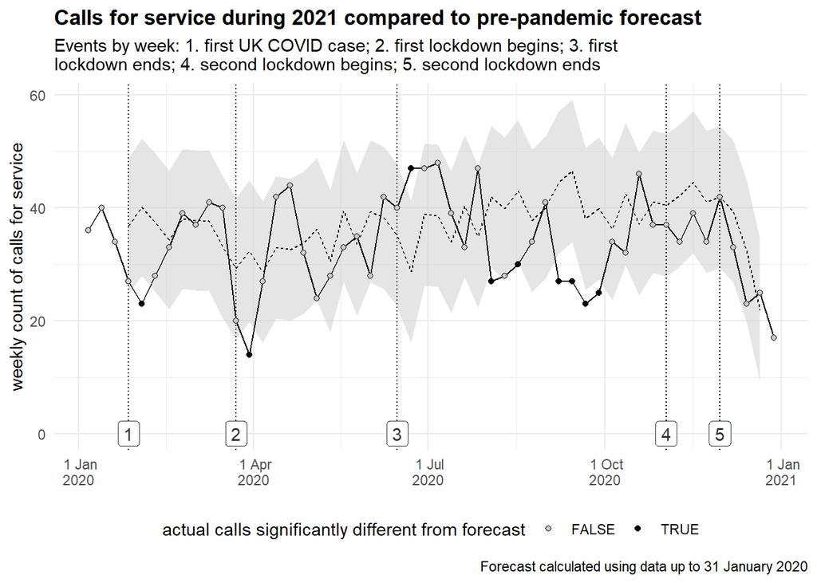

## Hate Incident

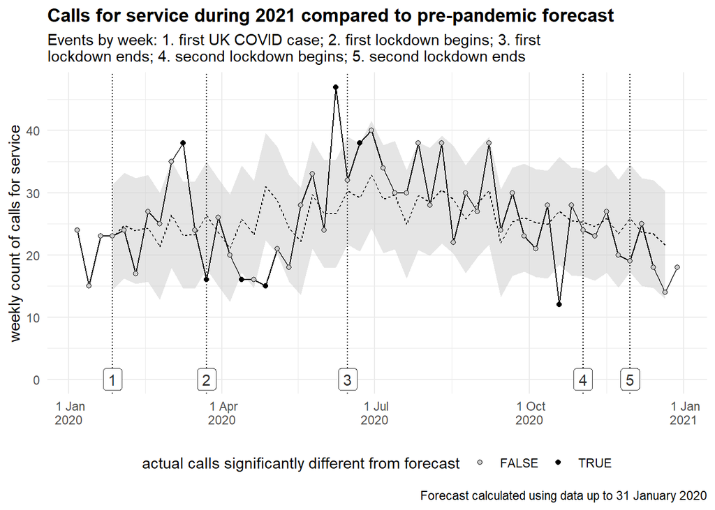

Overall actual calls do not significant differ from forecasted data. During the the first UK Covid case and the first lockdown, there are two points above the forecast data. There is also a general increase of hate incidents (within the CIs but still high) following the fist lockdown ending - reflective of increased biased and prejudice to certain communities

## Highway Disruption

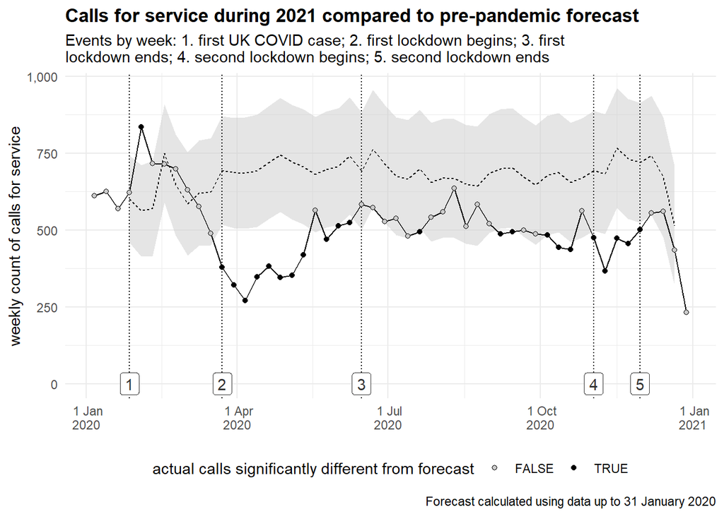

Significantly lower levels of highway disruption from the first lockdown as a result of less people traveling. Also supported by the small increase after the first lockdown ended (3)

## Missing Person

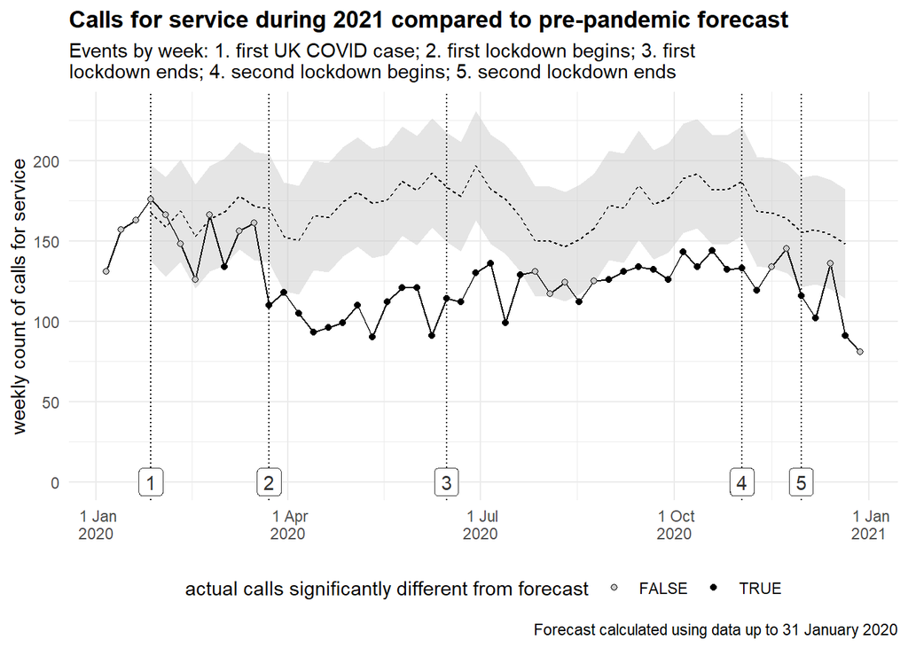

Significant differences again following the first lockdown. Supported by literature with more children being at home and less opportunity for ‘juvenile runaways’.

## Other - Admin Calls

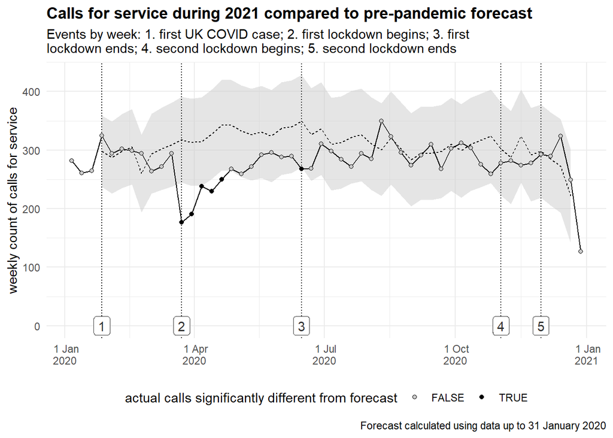

Small changes to admin calls following the first lockdown as expected with a decrease of weekly calls. However, typically the trends follows the overall forecast pattern

## Other - minor

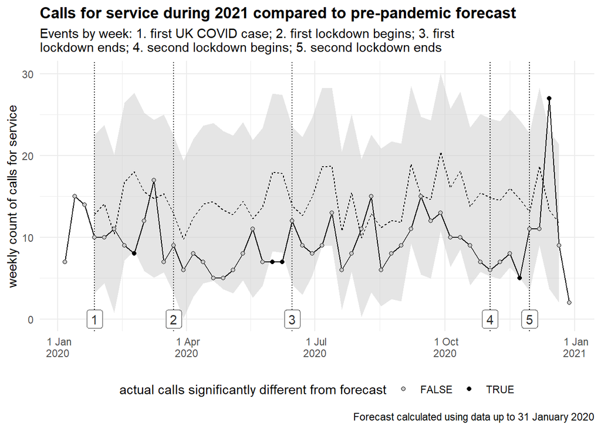

Actual calls generally fall within the CIs - no siginificant differences

## Police Generated

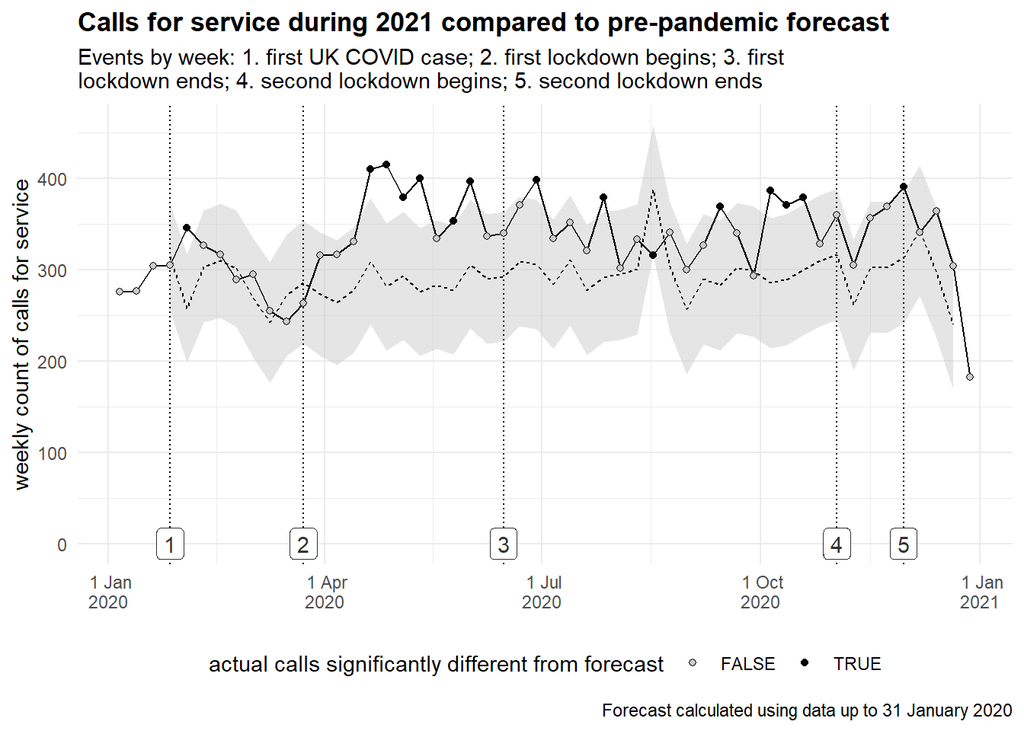

Interestingly, actual calls from police generated calls fall above the confidence interval throughout all 5 key dates. However, no clear trend in the changes instead some random fluctuations

## Potential Breach of the Peace

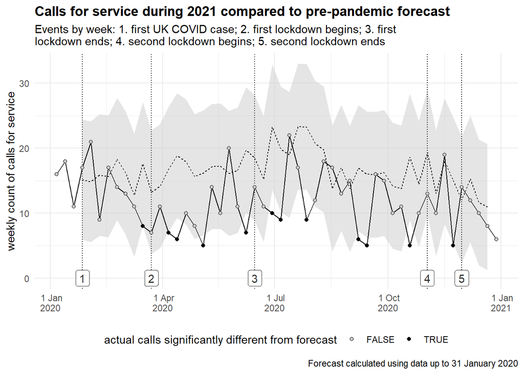

Actual calls of potential breach of peace are much lower than the forecasted data. This makes sense due to changes in peoples daily routine resulting in less opportunity to causes alarm and threat to the community

## Property Lost/Found

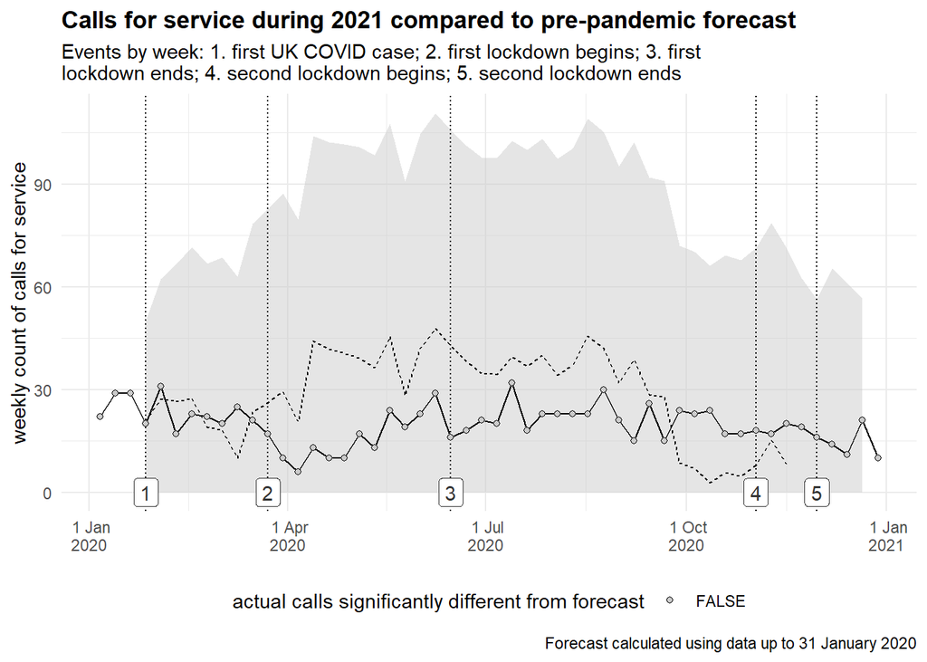

No obvious diferences between actual calls and forecasted data.

## Road Related Traffic Offence

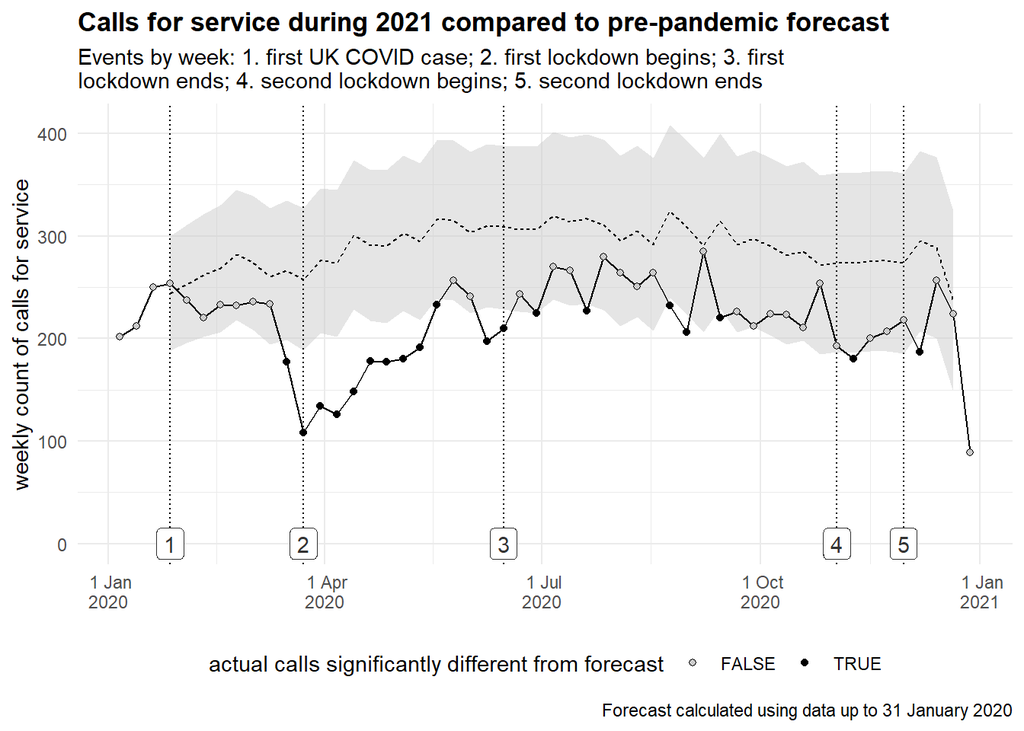

Actual calls of road related traffic offenses typically fall below the forecasted data. Again, this is expected due to less people traveling during the restrictions put in place and a reduction in able employees.

## Robbery

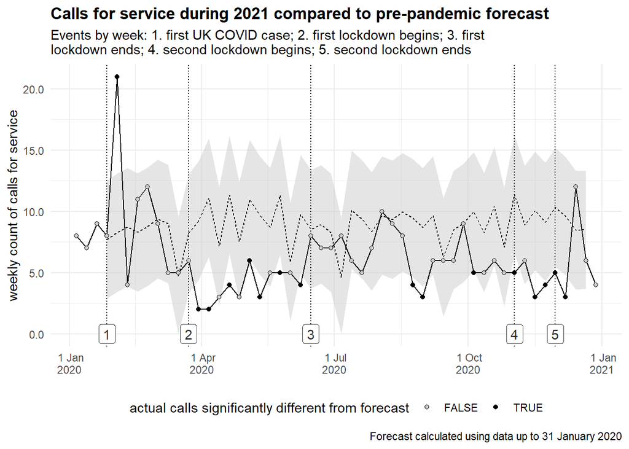

During time period one, there was a high spike in actual calls of robbery where the first UK Covid case happened - why is this? We also see a break in the seasonality and more random fluctuations throughout the five key dates. Arguably nothing too different from the forecasted data

## Sexual Offences

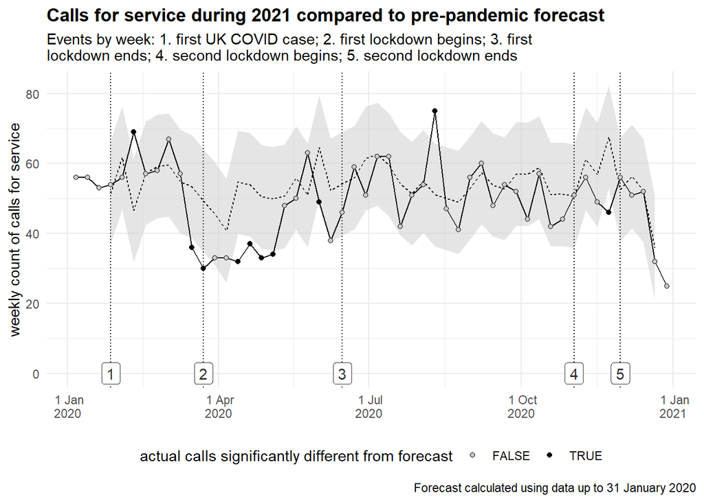

During the first lockdown cases of sexual offenses decreased and fell below the 95% confidence intervals, trends however return to normal following the end of the lockdown. No signifcant differences from the forecast data

## Shoplifitng

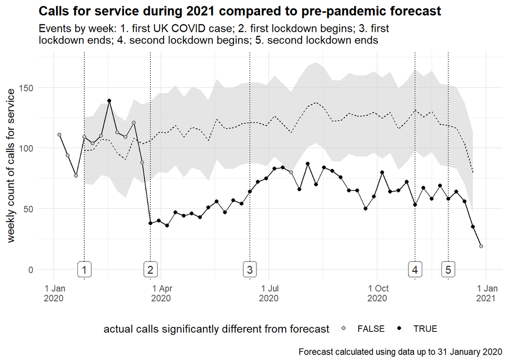

Significant differences following the first lockdown as would be expected due to closure of retail and businesses. Arguably different seasonality patterns as well

## Sudden Death

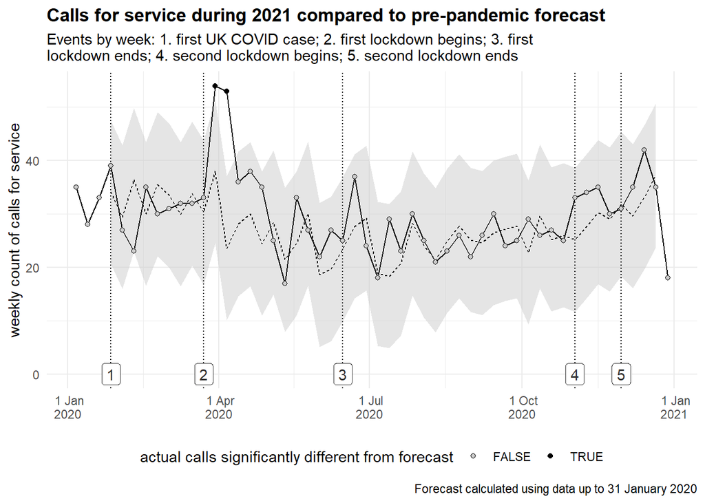

Two time periods are seen as significantly different from the forecast which happens at the start of the first UK lockdown, this could be as a result of increase Covid-19 cases or reduced information around the virus, Results tend to fall back to normal soon after. Overall, actual calls are not significantly different from forecast

## Suspicious Activity

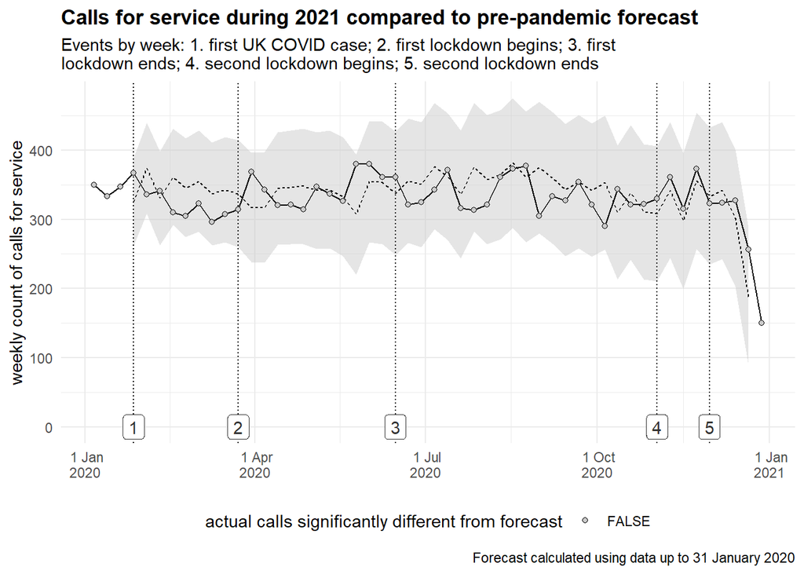

No significant differences in suspicious activity calls.

## Suspicious Package

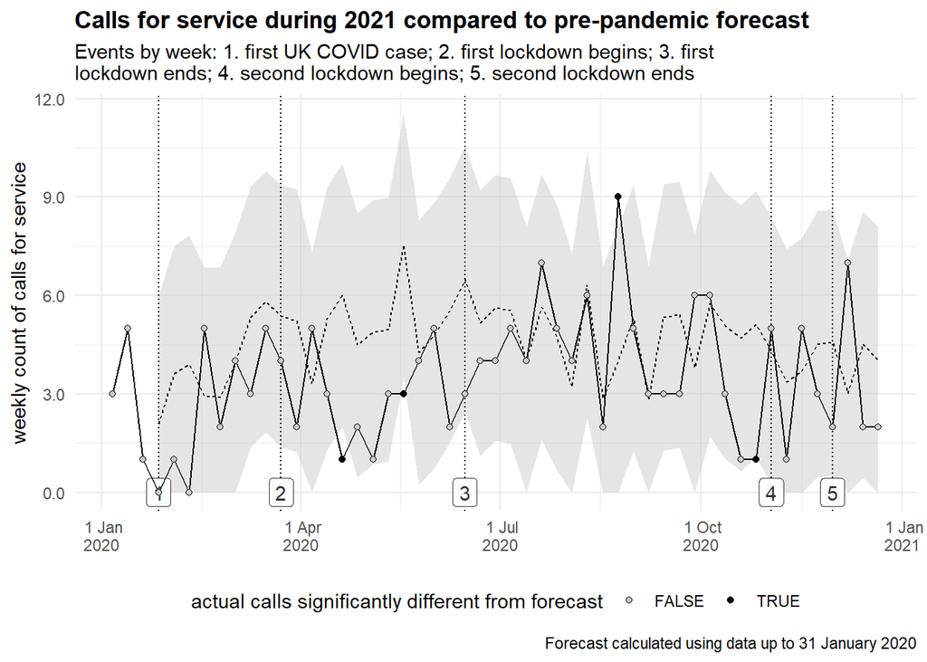

Arguable differences in actual calls compared to forecast data.